# Mediation in the APIM

Back to schedule

# Data Example

Read in the pairwise dataset

```r
library(nlme)
library(dyadr)
library(dplyr)

riggsp<- read.csv("riggsp.csv")

# Create variables with dplyr
riggsp <- riggsp %>%
  mutate(Woman = (Gender_A+1)/2,
         Man  = -(Gender_A-1)/2,
         Abuse_AW = Abuse_A*Woman,
         Abuse_PW = Abuse_P*Woman,
         Abuse_AM = Abuse_A*Man,
         Abuse_PM = Abuse_P*Man,
         Anxiety_AW = Anxiety_A*Woman,
         Anxiety_PW = Anxiety_P*Woman,
         Anxiety_AM = Anxiety_A*Man,
         Anxiety_PM = Anxiety_P*Man)
```

# Test of Moderation

Making sure the X variable does not moderate the effect of the mediator on the outcome.

Abuse (X), Anxiety (M), and their interaction (XM) affecting Satisfaction (Y)

Run with ML to test the eight possible interactions.

```r
apim_mm <-  gls(Sat_A ~ Gender_A + Anxiety_A + Anxiety_P + Abuse_A + Abuse_P
                + Anxiety_A*Gender_A + Anxiety_P*Gender_A
                + Abuse_A*Gender_A + Abuse_P*Gender_A
                + Anxiety_A*Abuse_A + Anxiety_P*Abuse_P
                + Anxiety_A*Abuse_P + Anxiety_P*Abuse_A
                + Anxiety_A*Abuse_A*Gender_A + Anxiety_P*Abuse_P*Gender_A
                + Anxiety_A*Abuse_P*Gender_A + Anxiety_P*Abuse_A*Gender_A,
                na.action = na.omit,
                correlation = corCompSymm(form=~1|Dyad),
                method="ML",
                weights = varIdent(form=~1|Gender_A),
                data = riggsp)

smallsummary(apim_mm)
```

```
## Correlation structure of class corCompSymm representing
##       Rho
## 0.6327318
##
## Variance function structure of class varIdent representing
##       -1        1
## 1.000000 1.021552
## Residual standard error: 6.484756
##
##                              Value Std.Error t-value p-value
## (Intercept)                54.0588    4.1213 13.1168  0.0000
## Gender_A                   -0.1542    1.9551 -0.0788  0.9372
## Anxiety_A                  -1.1823    0.8852 -1.3356  0.1827
## Anxiety_P                  -1.3816    0.8840 -1.5629  0.1192
## Abuse_A                    -0.2954    0.2580 -1.1448  0.2532
## Abuse_P                     0.1167    0.2571  0.4539  0.6503
## Gender_A:Anxiety_A          0.7340    1.0946  0.6706  0.5030
## Gender_A:Anxiety_P         -0.2279    1.0937 -0.2084  0.8351
## Gender_A:Abuse_A            0.0438    0.2870  0.1527  0.8787
## Gender_A:Abuse_P           -0.0239    0.2862 -0.0836  0.9334
## Anxiety_A:Abuse_A           0.0592    0.0750  0.7899  0.4303
## Anxiety_P:Abuse_P           0.0248    0.0748  0.3315  0.7405
## Anxiety_A:Abuse_P          -0.1010    0.0736 -1.3733  0.1707
## Anxiety_P:Abuse_A          -0.0061    0.0737 -0.0822  0.9345
## Gender_A:Anxiety_A:Abuse_A -0.1012    0.0770 -1.3144  0.1897
## Gender_A:Anxiety_P:Abuse_P -0.0299    0.0769 -0.3894  0.6973
## Gender_A:Anxiety_A:Abuse_P  0.0232    0.0782  0.2973  0.7665
## Gender_A:Anxiety_P:Abuse_A  0.0579    0.0782  0.7406  0.4596
```

```
##                              2.5 %  97.5 %
## (Intercept)                45.9812 62.1365
## Gender_A                   -3.9861  3.6778
## Anxiety_A                  -2.9173  0.5527
## Anxiety_P                  -3.1143  0.3510
## Abuse_A                    -0.8010  0.2103
## Abuse_P                    -0.3872  0.6206
## Gender_A:Anxiety_A         -1.4114  2.8795
## Gender_A:Anxiety_P         -2.3714  1.9157
## Gender_A:Abuse_A           -0.5187  0.6063
## Gender_A:Abuse_P           -0.5848  0.5369
## Anxiety_A:Abuse_A          -0.0877  0.2061
## Anxiety_P:Abuse_P          -0.1219  0.1715
## Anxiety_A:Abuse_P          -0.2453  0.0432
## Anxiety_P:Abuse_A          -0.1505  0.1383
## Gender_A:Anxiety_A:Abuse_A -0.2522  0.0497
## Gender_A:Anxiety_P:Abuse_P -0.1807  0.1208
## Gender_A:Anxiety_A:Abuse_P -0.1300  0.1764
## Gender_A:Anxiety_P:Abuse_A -0.0954  0.2113
```

We do see that none of the 8 tests are significant, but to be sure we do combined tests of the 8 effects.

```r
apim_base <-  gls(Sat_A ~ Gender_A + Anxiety_A + Anxiety_P
                  + Abuse_A + Abuse_P
                  + Anxiety_A*Gender_A + Anxiety_P*Gender_A
                  + Abuse_A*Gender_A + Abuse_P*Gender_A,
                  na.action = na.omit,
                  correlation = corCompSymm(form=~1|Dyad),
                  method = "ML",
                  weights = varIdent(form=~1|Gender_A),
                  data = riggsp)

anova(apim_mm, apim_base)
```

```
##           Model df      AIC      BIC    logLik   Test  L.Ratio p-value
## apim_mm       1 21 2008.145 2086.613 -983.0727
## apim_base     2 13 2000.960 2049.535 -987.4800 1 vs 2 8.814498  0.3582
```

# Distinguishable Dyads

## The Four Baron & Kenny Steps Using Multilevel Modeling

### Step 1: Estimating and testing the total effect (c) of Abuse (X) on Satisfaction (Y)

```r
apim_stp1 <- gls(Sat_A ~ -1 + Woman + Man
                 + Abuse_AW + Abuse_PW + Abuse_AM + Abuse_PM,
                 na.action=na.omit, correlation=corCompSymm (form=~1|Dyad),
                 weights=varIdent(form=~1|Gender_A),data=riggsp)

smallsummary(apim_stp1)
```

```
## Correlation structure of class corCompSymm representing
##       Rho
## 0.6642598
##
## Variance function structure of class varIdent representing
##       -1        1
## 1.000000 1.003592
## Residual standard error: 7.121407
##
##            Value Std.Error t-value p-value
## Woman    50.5948    1.6479 30.7023  0.0000
## Man      48.0010    1.6420 29.2329  0.0000
## Abuse_AW -0.4178    0.1192 -3.5043  0.0005
## Abuse_PW -0.2250    0.1376 -1.6358  0.1029
## Abuse_AM -0.1795    0.1371 -1.3099  0.1912
## Abuse_PM -0.1744    0.1188 -1.4678  0.1432
```

```
##            2.5 %  97.5 %
## Woman    47.3650 53.8247
## Man      44.7827 51.2193
## Abuse_AW -0.6515 -0.1841
## Abuse_PW -0.4947  0.0446
## Abuse_AM -0.4482  0.0891
## Abuse_PM -0.4072  0.0585
```

### Step 2: Testing the effects of the Abuse (X) on Anxiety (M).

```r
apim_stp2 <-  gls(Anxiety_A ~ -1 + Woman + Man
                     + Abuse_AW + Abuse_PW + Abuse_AM + Abuse_PM,
                     na.action=na.omit, correlation=corCompSymm (form=~1|Dyad),
                     weights=varIdent(form=~1|Gender_A),data=riggsp)

smallsummary(apim_stp2)
```

```
## Correlation structure of class corCompSymm representing
##       Rho
## 0.1656898
##
## Variance function structure of class varIdent representing
##        -1         1
## 1.0000000 0.9013311
## Residual standard error: 1.246035
##
##           Value Std.Error t-value p-value
## Woman    1.9282    0.2590  7.4461  0.0000
## Man      1.9629    0.2873  6.8320  0.0000
## Abuse_AW 0.0931    0.0187  4.9701  0.0000
## Abuse_PW 0.0143    0.0216  0.6625  0.5082
## Abuse_AM 0.0556    0.0240  2.3203  0.0210
## Abuse_PM 0.0218    0.0208  1.0488  0.2951
```

```
##            2.5 % 97.5 %
## Woman     1.4207 2.4358
## Man       1.3998 2.5260
## Abuse_AW  0.0564 0.1298
## Abuse_PW -0.0280 0.0567
## Abuse_AM  0.0086 0.1027
## Abuse_PM -0.0189 0.0625
```

#### Interpretation:

All four paths of the “a” paths are positive but only the two actor effects are statistically significant: More childhood abuse leads at anxious attachment for yourself, but not for your partner.

### Steps 3 and 4: Testing the effects of the Anxiety (M) and Abuse (X) on the Satisfaction (Y).

```r
apim_stp34 <-  gls(Sat_A ~ -1 + Woman + Man
                     + Anxiety_AW + Anxiety_PW + Anxiety_AM + Anxiety_PM
                     + Abuse_AW + Abuse_PW + Abuse_AM + Abuse_PM,
                     na.action=na.omit,
                     correlation=corCompSymm (form=~1|Dyad),
                     weights=varIdent(form=~1|Gender_A),data=riggsp)
smallsummary(apim_stp34)
```

```
## Correlation structure of class corCompSymm representing
##       Rho
## 0.6201065
##
## Variance function structure of class varIdent representing
##       -1        1
## 1.000000 1.011957
## Residual standard error: 6.674376
##
##              Value Std.Error t-value p-value
## Woman      55.9097    1.9556 28.5903  0.0000
## Man        53.4614    1.9324 27.6652  0.0000
## Anxiety_AW -1.5250    0.4946 -3.0831  0.0022
## Anxiety_PW -1.2097    0.4458 -2.7133  0.0070
## Anxiety_AM -1.6341    0.4406 -3.7092  0.0002
## Anxiety_PM -1.1684    0.4888 -2.3904  0.0174
## Abuse_AW   -0.2494    0.1215 -2.0529  0.0409
## Abuse_PW   -0.1359    0.1323 -1.0268  0.3053
## Abuse_AM   -0.0719    0.1308 -0.5497  0.5829
## Abuse_PM   -0.0300    0.1201 -0.2495  0.8032
```

```
##              2.5 %  97.5 %
## Woman      52.0769 59.7426
## Man        49.6739 57.2489
## Anxiety_AW -2.4945 -0.5555
## Anxiety_PW -2.0835 -0.3359
## Anxiety_AM -2.4976 -0.7706
## Anxiety_PM -2.1264 -0.2104
## Abuse_AW   -0.4876 -0.0113
## Abuse_PW   -0.3952  0.1235
## Abuse_AM   -0.3282  0.1844
## Abuse_PM   -0.2653  0.2054
```

**Step 3**: All four “b” paths from Anxiety to Satisfaction are negative and statistically significant: Having a more anxious attachment style leads to less satisfaction for you and your partner, even after controlling for childhood abuse.

**Step 4**: All paths from Abuse to Satisfaction, c’, are negative but only the actor effect for women is statistically significant: Being abused as a child leads to lower levels of satisfaction, even after controlling for yours and your partner’s anxious attachment.

```r
# a or X --> M effects and standard errors
act_M_a <- coef(summary(apim_stp2))[5,1]
act_W_a <- coef(summary(apim_stp2))[3,1]
part_M_a <- coef(summary(apim_stp2))[6,1]
part_W_a <- coef(summary(apim_stp2))[4,1]
act_M_a_se <- coef(summary(apim_stp2))[5,2]
act_W_a_se <- coef(summary(apim_stp2))[3,2]
part_M_a_se <- coef(summary(apim_stp2))[6,2]
part_W_a_se <- coef(summary(apim_stp2))[4,2]
# b or M --> Y effects
act_M_b <- coef(summary(apim_stp34))[5,1]
act_W_b <- coef(summary(apim_stp34))[3,1]
part_M_b <- coef(summary(apim_stp34))[6,1]
part_W_b <- coef(summary(apim_stp34))[4,1]
act_M_b_se <- coef(summary(apim_stp34))[5,2]
act_W_b_se <- coef(summary(apim_stp34))[3,2]
part_M_b_se <- coef(summary(apim_stp34))[6,2]
part_W_b_se <- coef(summary(apim_stp34))[4,2]
# c or X --> Y total effects
act_M_c <- coef(summary(apim_stp1))[5,1]
act_W_c <- coef(summary(apim_stp1))[3,1]
part_M_c <- coef(summary(apim_stp1))[6,1]
part_W_c <- coef(summary(apim_stp1))[4,1]
# cp or X --> Y direct effects
act_M_cp <- coef(summary(apim_stp34))[9,1]
act_W_cp <- coef(summary(apim_stp34))[7,1]
part_M_cp <- coef(summary(apim_stp34))[10,1]
part_W_cp <- coef(summary(apim_stp34))[8,1]

#The Eight Indirect Effects
#  Actor-Actor
AA_M_IE <- act_M_a*act_M_b
AA_W_IE <- act_W_a*act_W_b
#  Actor-Partner
AP_M_IE <- act_W_a*part_M_b
AP_W_IE <- act_M_a*part_W_b
#  Partner-Actor
PA_M_IE <- part_M_a*act_M_b
PA_W_IE <- part_W_a*act_W_b
#  Partner-Partner
PP_M_IE <- part_W_a*part_M_b
PP_W_IE <- part_M_a*part_W_b

#Testing Indirect Effects Using Multilevel Modeling


# The 95% confidence interval for Men AA indrect effect:
CI_AA_M = mmc(act_M_a, act_M_b, act_M_a_se, act_M_b_se)
# The 95% confidence interval for Women AA indrect effect:
CI_AA_W = mmc(act_W_a, act_W_b, act_W_a_se, act_W_b_se)
# The 95% confidence interval for Men AP indrect effect:
CI_AP_M = mmc(act_W_a, part_M_b, act_W_a_se, part_M_b_se)
# The 95% confidence interval for Women AP indrect effect:
CI_AP_W = mmc(act_M_a, part_W_b, act_M_a_se, part_W_b_se)
# The 95% confidence interval for Men PA indrect effect:
CI_PA_M = mmc(part_M_a, act_M_b, part_M_a_se, act_M_b_se)
# The 95% confidence interval for Women PA indrect effect:
CI_PA_W = mmc(part_W_a, act_W_b, part_W_a_se, act_W_b_se)
# The 95% confidence interval for Men PP indrect effect:
CI_PP_M = mmc(part_W_a, part_M_b, part_W_a_se, part_M_b_se)
# The 95% confidence interval for Women PP indrect effect:
CI_PP_W = mmc(part_M_a, part_W_b, part_M_a_se, part_W_b_se)
```

The dyadr function mmc computes the Monte Carlo confidence intervals for indirect effects It is an adaptation of the function MCMAM written by Selig and Preacher (2008). It has four pieces of information in this order: a (the X to M effect), b (the M to Y effect), standard error of a, and the standard error of b. (For other parameters look at ?mmc.)

## Indirect Effects

| Name | Indirect Effects | Estimate | p | 95% CI Lower | Upper |
| --- | --- | --- | --- | --- | --- |
| Actor-Actor: M | Xm -> Mm -> Ym | -0.091 | 0.02 | -0.196 | -0.012 |
| Actor-Actor: W | Xw -> Mw -> Yw | -0.142 | 0.002 | -0.26 | -0.047 |
| Partner-Partner: M | Xm -> Mw -> Ym | -0.017 | 0.515 | -0.08 | 0.035 |
| Partner-Partner: W | Xw -> Mm -> Yw | -0.026 | 0.294 | -0.091 | 0.023 |
| Actor-Partner: M | Xw -> Mw -> Ym | -0.109 | 0.017 | -0.219 | -0.019 |
| Actor-Partner: W | Xm -> Mm -> Yw | -0.067 | 0.027 | -0.158 | -0.005 |
| Partner-Actor: M | Xw -> Mm -> Ym | -0.036 | 0.289 | -0.115 | 0.031 |
| Partner-Actor: W | Xm -> Mw -> YW | -0.022 | 0.507 | -0.099 | 0.044 |

Note that p value and lower and upper limits of the confidence interval will differ slightly because they are based on Monte Carlo estimates.

## Direct and Total Effects

| Name | Direct Effects | Direct | Total | % Mediated |
| --- | --- | --- | --- | --- |
| Actor: Man | Xm -> Ym | -0.072 | -0.18 | 60 |
| Actor: Woman | Xw -> Yw | -0.249 | -0.418 | 40.3 |
| Partner: Man | Xw -> Ym | -0.03 | -0.174 | 82.8 |
| Partner: Woman | Xm -> Yw | -0.136 | -0.225 | 39.6 |

Note that `% Mediated` equals `ab/c` or equivalently `1 - c'/c`. This value can be larger than one or negative. Make sure that the total effect is non-trivial before interpreting these values.

## Interpretation

# Indistinguishable: Gender Ignored

## Baron & Kenny Steps

### Step 1

```r
step1i  = gls(Sat_A ~ Abuse_A + Abuse_P ,
                 na.action=na.omit,
                 correlation=corCompSymm (form=~1|Dyad),
                 data=riggsp)
smallsummary(step1i)
```

```
## Correlation structure of class corCompSymm representing
##       Rho
## 0.6591908
##
## Residual standard error: 7.128683
##
##               Value Std.Error t-value p-value
## (Intercept) 49.3561    1.4933 33.0509  0.0000
## Abuse_A     -0.3153    0.0873 -3.6094  0.0004
## Abuse_P     -0.1955    0.0873 -2.2386  0.0259
```

```
##               2.5 %  97.5 %
## (Intercept) 46.4292 52.2829
## Abuse_A     -0.4865 -0.1441
## Abuse_P     -0.3667 -0.0243
```

Both actor and partner effects are statistically significant.

### Step 2

```r
step2i  = gls(Anxiety_A ~ Abuse_A + Abuse_P ,
                 na.action=na.omit,
                 correlation=corCompSymm (form=~1|Dyad),
                 data=riggsp)
smallsummary(step2i)
```

```
## Correlation structure of class corCompSymm representing
##       Rho
## 0.1581534
##
## Residual standard error: 1.189104
##
##              Value Std.Error t-value p-value
## (Intercept) 1.9316    0.2081  9.2814  0.0000
## Abuse_A     0.0803    0.0148  5.4273  0.0000
## Abuse_P     0.0151    0.0148  1.0231  0.3071
```

```
##               2.5 % 97.5 %
## (Intercept)  1.5237 2.3395
## Abuse_A      0.0513 0.1093
## Abuse_P     -0.0139 0.0441
```

Only the actor effect is statistically significant.

### Steps 3 and 4

```r
step34i  = gls(Sat_A ~ Anxiety_A + Anxiety_P + Abuse_A + Abuse_P,
                 na.action=na.omit,
                 correlation=corCompSymm (form=~1|Dyad),
                 data=riggsp)
smallsummary(step34i)
```

```
## Correlation structure of class corCompSymm representing
##       Rho
## 0.6143927
##
## Residual standard error: 6.682944
##
##               Value Std.Error t-value p-value
## (Intercept) 54.7324    1.7265 31.7021  0.0000
## Anxiety_A   -1.6013    0.3089 -5.1836  0.0000
## Anxiety_P   -1.1820    0.3089 -3.8264  0.0002
## Abuse_A     -0.1688    0.0865 -1.9521  0.0518
## Abuse_P     -0.0764    0.0865 -0.8834  0.3777
```

```
##               2.5 %  97.5 %
## (Intercept) 51.3486 58.1162
## Anxiety_A   -2.2068 -0.9958
## Anxiety_P   -1.7875 -0.5766
## Abuse_A     -0.3383  0.0007
## Abuse_P     -0.2459  0.0931
```

Direct effects are not significant, but the “b” paths, both actor and partner, are significant.

```r
# a or X --> M effects and standard errors
act_a <- coef(summary(step2i))[2,1]
part_a <- coef(summary(step2i))[3,1]
act_a_se <- coef(summary(step2i))[2,2]
part_a_se <- coef(summary(step2i))[3,2]

# b or M --> Y effects
act_b <- coef(summary(step34i))[2,1]
part_b <- coef(summary(step34i))[3,1]
act_b_se <- coef(summary(step34i))[2,2]
part_b_se <- coef(summary(step34i))[3,2]

# c or X --> Y total effects
act_c <- coef(summary(step1i))[2,1]
part_c <- coef(summary(step1i))[3,1]

# cp or X --> Y direct effects

act_cp <- coef(summary(step34i))[4,1]
part_cp <- coef(summary(step34i))[5,1]

##Indirect Effects

#  Actor-Actor
AA_IE <- act_a*act_b
#  Actor-Partner
AP_IE <- act_a*part_b
#  Partner-Actor
PA_IE <- part_a*act_b
#  Partner-Partner
PP_IE <- part_a*part_b

# The 95% confidence interval for AA indrect effect:
CI_AA = mmc(act_a, act_b, act_a_se, act_b_se)
# The 95% confidence interval for AP indrect effect:
CI_AP = mmc(act_a, part_b, act_a_se, part_b_se)
# The 95% confidence interval for PA indrect effect:
CI_PA = mmc(part_a, act_b, part_a_se, act_b_se)
# The 95% confidence interval for Men PP indrect effect:
CI_PP = mmc(part_a, part_b, part_a_se, part_b_se)
```

## Indirect Effects

| Name | Indirect Effects | Estimate | p | 95% CI Lower | Upper |
| --- | --- | --- | --- | --- | --- |
| Actor-Actor | X1 -> M1 -> Y1 | -0.129 | 0 | -0.202 | -0.068 |
| Partner-Partner | X1 -> M2 -> Y1 | -0.018 | 0.302 | -0.058 | 0.017 |
| Actor-Partner | X2 -> M2 -> Y1 | -0.095 | 0 | -0.161 | -0.041 |
| Partner-Actor | X1 -> M2 -> Y1 | -0.024 | 0.302 | -0.076 | 0.022 |

Note that p value and lower and upper limits of the confidence interval will differ slightly because they are based on Monte Carlo estimates.

## Direct and Total Effects

| Name | Direct Effects | Direct | Total | % Mediated |
| --- | --- | --- | --- | --- |
| Actor | X1 -> Y1 | -0.169 | -0.315 | 46.5 |
| Partner | X2 -> Y1 | -0.076 | -0.196 | 60.9 |

Note that `% Mediated` equals `ab/c` or equivalently `1 - c'/c`. This value can be larger than one or negative. Make sure that the total effect is non-trivial before interpreting these values.

## Interpretation

**Actor-Actor** —People who report more abuse are more anxiously attached and are then less satisfied.  
**Partner-Partner** —People who report more abuse have partners who are more anxiously attached and they in turn are less satisfied.  
**Actor-Partner** —People who report more abuse are more anxiously attached and their partners in turn are less satisfied.  
**Partner-Actor** —People who report more abuse have partners who are more anxiously attached and those partners are less satisfied.

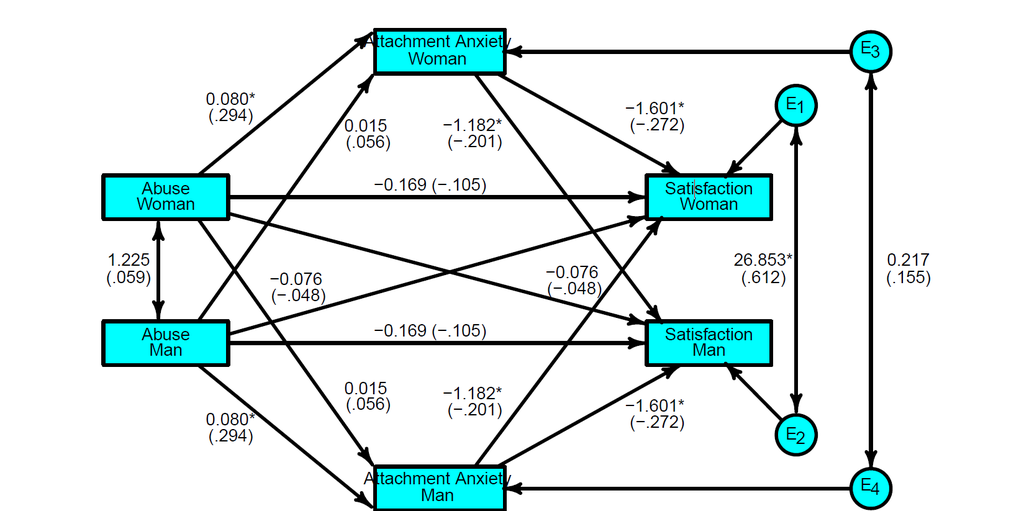

(diagram taken from the app APIM_MM)

Back to schedule